# Confidence estimation

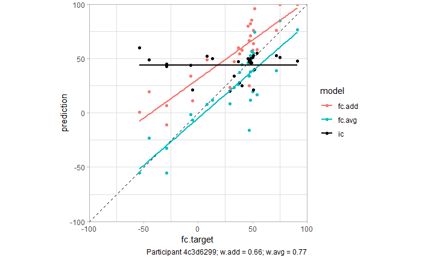

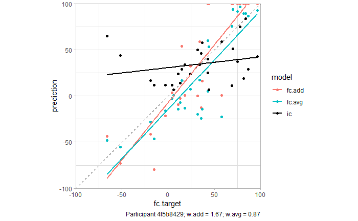

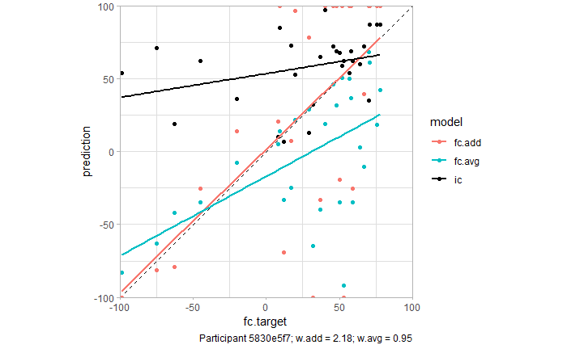

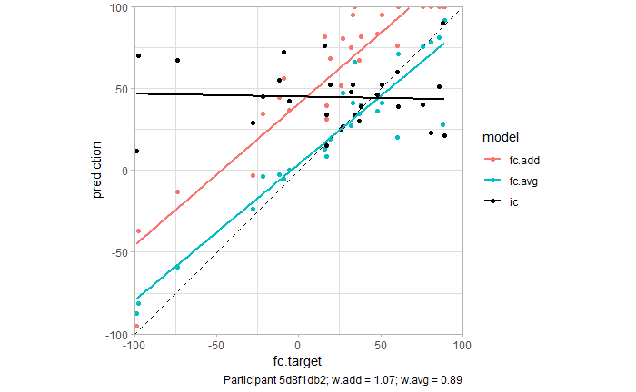

[18 more figures not shown]

This pattern may be dominated by disagreeing trials, which have a more intuitive presentation where averaging produces a more add-like final answer. So let’s just look at agreement trials. We also only want those trials where the participant didn’t (rather inexplicably given agreement) change their mind. Again, we plot a few graphs to see how things look.

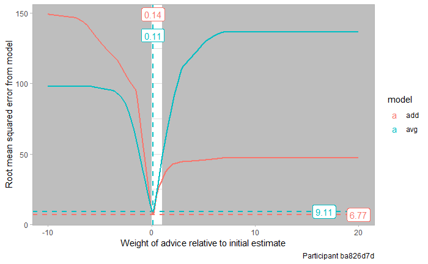

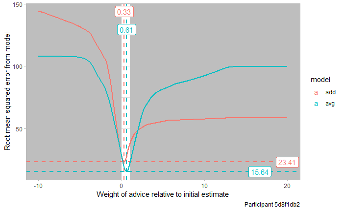

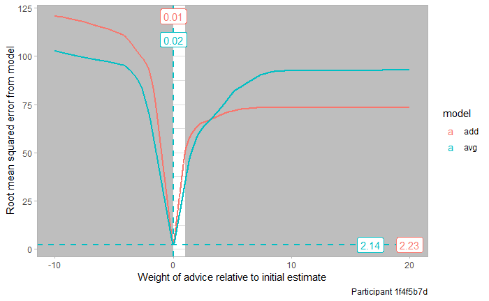

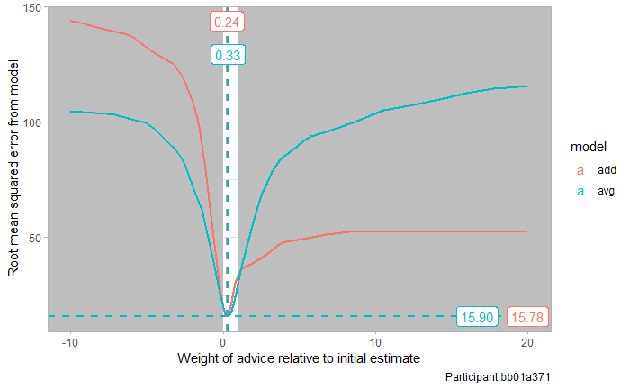

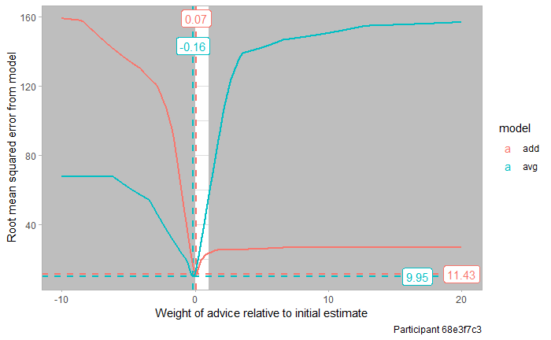

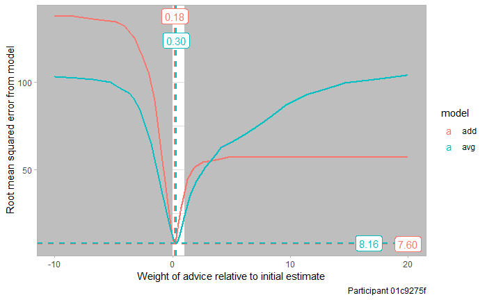

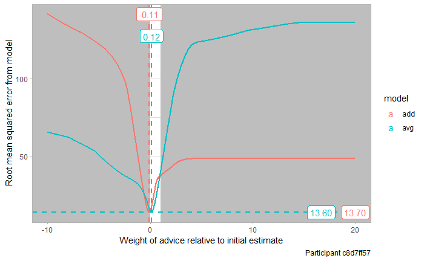

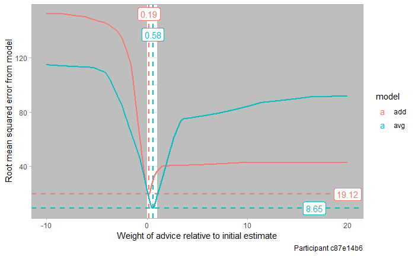

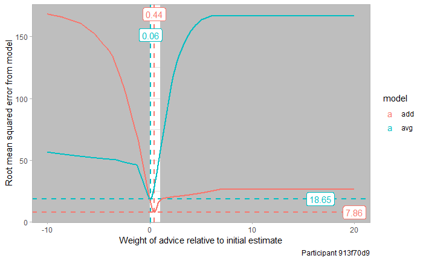

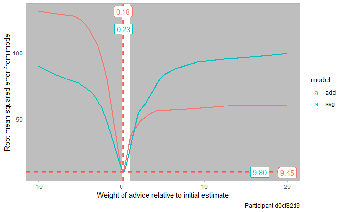

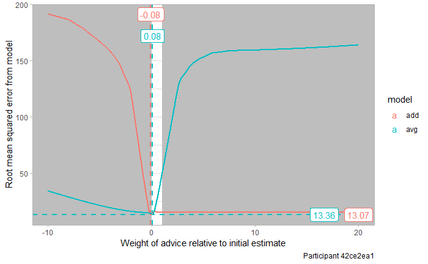

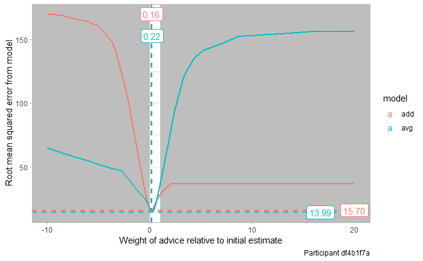

[18 more figures not shown]

| model | okx |
| --- | --- |
| add | 0.8333333 |
| avg | 0.9666667 |

| okboth | okneither | avgBest |
| --- | --- | --- |
| 0.8 | 0 | 0.4333333 |

```
attributes are not identical across measure variables;
they will be dropped
```

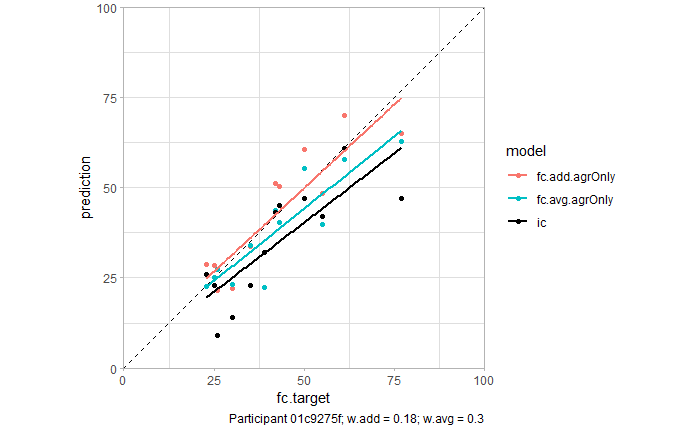

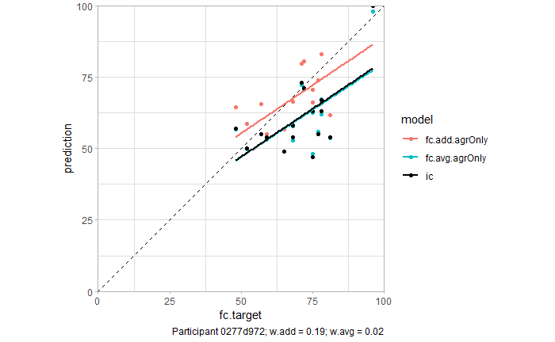

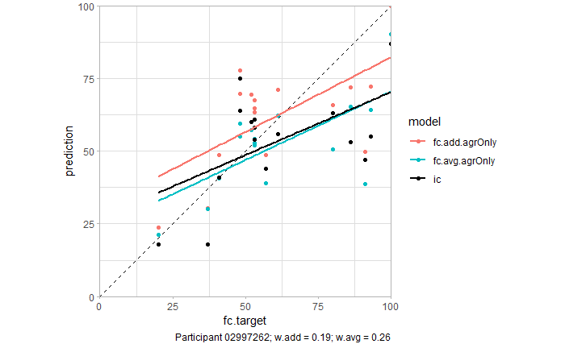

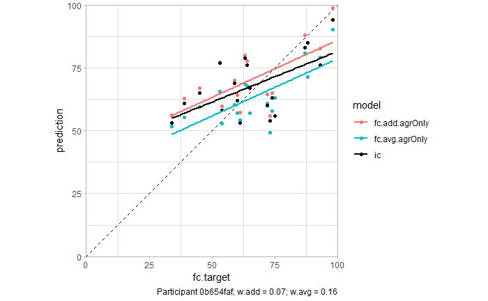

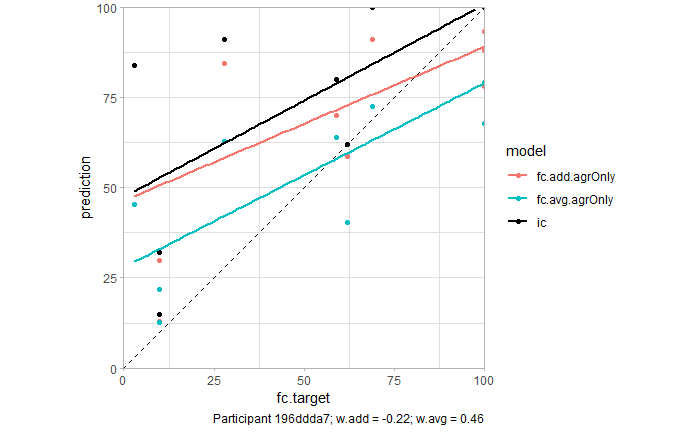

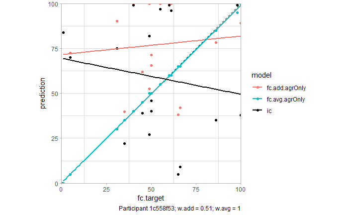

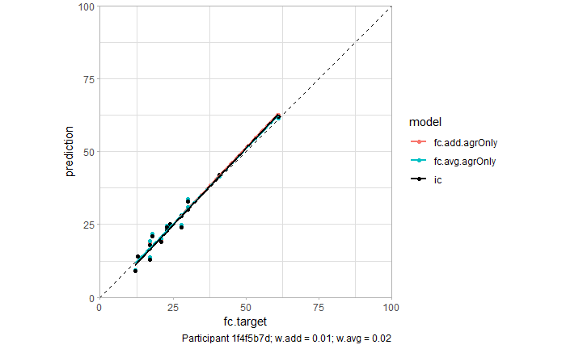

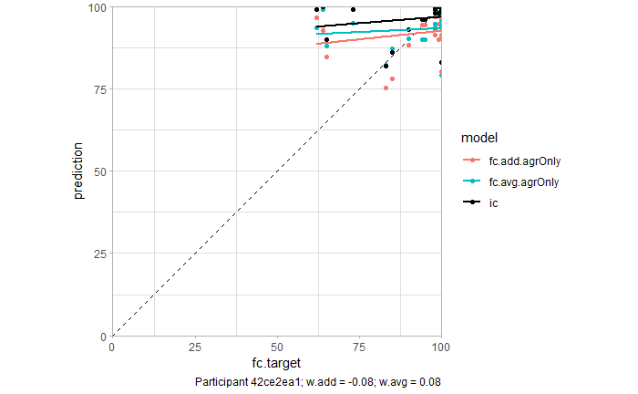

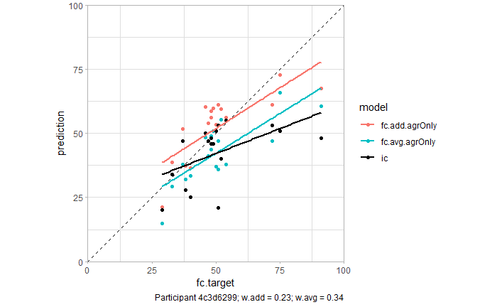

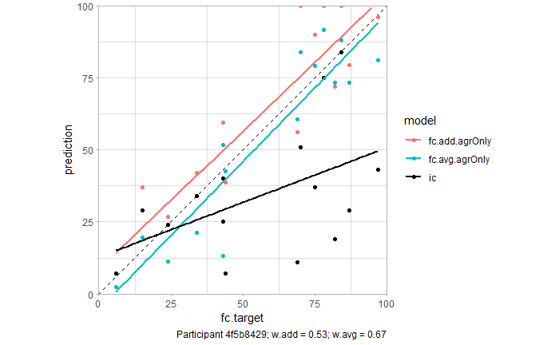

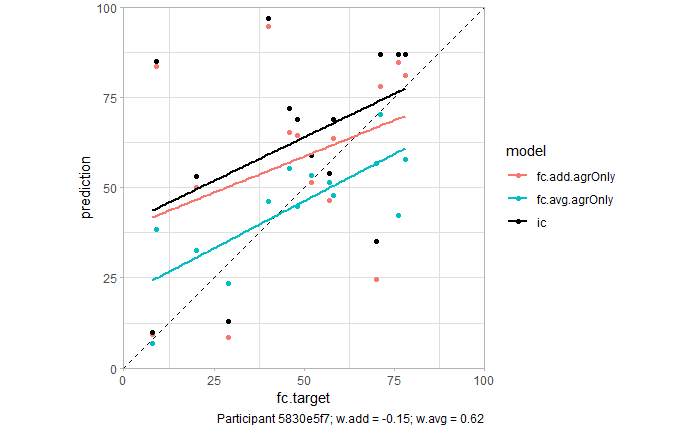

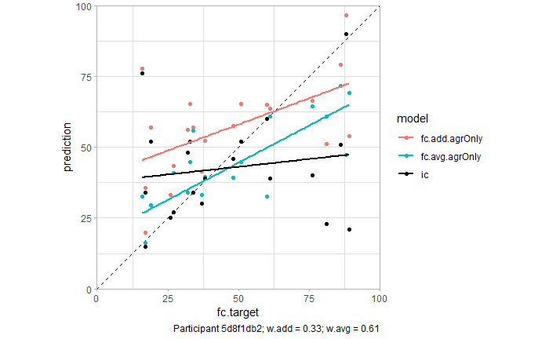

[18 more figures not shown]

Another way we can look at this is to ask what the probability of increasing your confidence is, given you answer in the same direction and the advisor agreed with you. Rationally, you should always increase your confidence, but if you’re doing visual averaging you’ll always decrease your confidence.

| pid | p(increase\|ihigh=FALSE) | p(increase\|ihigh=TRUE) |
| --- | --- | --- |
| 01c9275f | 0.8571429 | 0.50000000 |
| 0277d972 | 1.0000000 | 0.75000000 |
| 02997262 | 1.0000000 | 0.33333333 |
| 0b654faf | 1.0000000 | 0.33333333 |
| 196ddda7 | NA | 0.00000000 |
| 1c558f53 | 1.0000000 | 0.00000000 |
| 1f4f5b7d | 0.5000000 | 0.00000000 |
| 42ce2ea1 | 0.7500000 | 0.21428571 |
| 4c3d6299 | 1.0000000 | 0.25000000 |
| 4f5b8429 | 1.0000000 | 0.33333333 |

[output cut: 20 more lines]

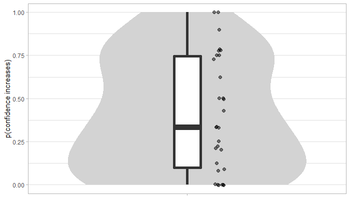

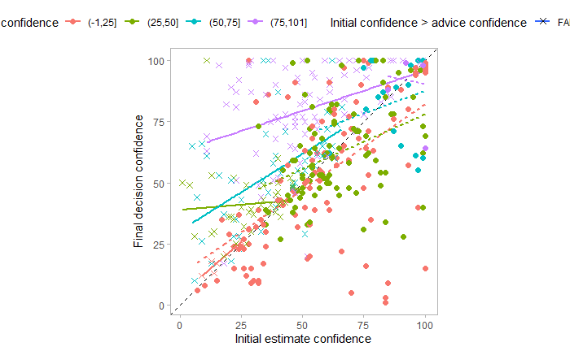

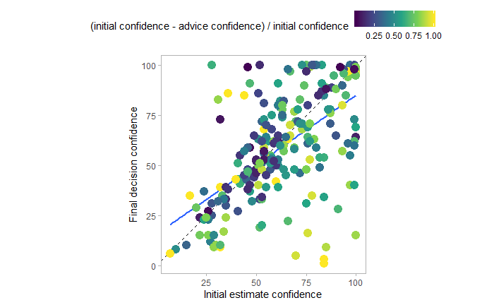

### Prettier influence graph

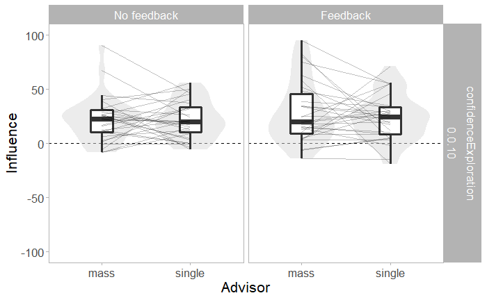

# Conclusions

# Credits

## Acknowledgements

Thanks as always to Nick Yeung and the other folks at the [ACC Lab](https://www.psy.ox.ac.uk/research/attention-cognitive-control-lab).

## Funding

Matt Jaquiery is funded by a studentship from the [Medical Research Council](https://mrc.ukri.org/) (reference 1943590) and the University of Oxford [Department of Experimental Psychology](https://www.psy.ox.ac.uk/) (reference 17/18_MSD_661552).